# Praktikum 6 Analisis Regresi

# Library

```r
library(readxl)
library(GGally)
```

```r
library(corrplot)
library(dplyr)
library(car)
library(stargazer)
library(lmtest)
library(olsrr)
dt <- read_xlsx(
"C:\\Users\\USER\\OneDrive\\ドキュメント\\Mata Kuliah Semester 4\\Analisis Regresi\\Data Pengangguran_Qurrota A'yunina_M0401241049.xlsx",
sheet = "Data"
)

dt
```

```
## # A tibble: 38 × 8
##    Provinsi          Y    X1    X2       X3    X4       X5       X6
##    <chr>         <dbl> <dbl> <dbl>    <dbl> <dbl>    <dbl>    <dbl>
##  1 Aceh           5.64 10.4  14.2  1299756.  36.2 3685616   4155944
##  2 Bali           1.49 10.1   4    1964618.  74.3 2996561   3547519
##  3 Banten         6.69  9.82  5.84 1750546.  73.7 3876600   9539824
##  4 Bengkulu       3.41  9.71 13.6  1498744.  33.5 2905120.  1608738
##  5 DI Yogyakarta  3.46 10.6  10.8  1843212.  78   2670039.  3049126
##  6 DKI Jakarta    6.05 11.6   4.3  2962412. 100   2264081.  8430623
##  7 Gorontalo      3.42  8.78 14.6  1315738.  48.9 5396761    946299
##  8 Jambi          4.26  9.32  7.1  1477104.  34.8 3221731   2829000
##  9 Jawa Barat     6.77  9.46  7.46 1724367.  83.1 3234535  39237385
## 10 Jawa Tengah    4.66  8.62 10.5  1337028.  54.3 2191232. 30037087
## # ℹ 28 more rows
```

```r
str(dt)
```

```
## tibble [38 × 8] (S3: tbl_df/tbl/data.frame)
##  $ Provinsi: chr [1:38] "Aceh" "Bali" "Banten" "Bengkulu" ...
##  $ Y       : num [1:38] 5.64 1.49 6.69 3.41 3.46 6.05 3.42 4.26 6.77 4.66 ...
##  $ X1      : num [1:38] 10.42 10.07 9.82 9.71 10.58 ...
##  $ X2      : num [1:38] 14.23 4 5.84 13.56 10.83 ...
##  $ X3      : num [1:38] 1299756 1964618 1750546 1498744 1843212 ...
##  $ X4      : num [1:38] 36.2 74.3 73.7 33.5 78 100 48.9 34.8 83.1 54.3 ...
##  $ X5      : num [1:38] 3685616 2996561 3876600 2905120 2670039 ...
##  $ X6      : num [1:38] 4155944 3547519 9539824 1608738 3049126 ...
```

```r
summary(dt)
```

```
##    Provinsi               Y               X1               X2
##  Length:38          Min.   :1.490   Min.   : 4.760   Min.   : 4.00
##  Class :character   1st Qu.:3.500   1st Qu.: 8.932   1st Qu.: 6.32
##  Mode  :character   Median :4.210   Median : 9.575   Median :10.13
##                     Mean   :4.468   Mean   : 9.457   Mean   :11.15
##                     3rd Qu.:5.545   3rd Qu.:10.092   3rd Qu.:14.06
##                     Max.   :6.960   Max.   :11.580   Max.   :32.97
##        X3                X4               X5                X6
##  Min.   :1028875   Min.   : 23.00   Min.   :2169349   Min.   :  336718
##  1st Qu.:1368587   1st Qu.: 37.90   1st Qu.:2907590   1st Qu.: 1171362
##  Median :1495638   Median : 52.80   Median :3321268   Median : 2939063
##  Mean   :1589662   Mean   : 53.99   Mean   :3315762   Mean   : 5741258
##  3rd Qu.:1744522   3rd Qu.: 73.19   3rd Qu.:3649059   3rd Qu.: 4896332
##  Max.   :2962412   Max.   :100.00   Max.   :5396761   Max.   :39237385
```

Data yang digunakan adalah data tingkat pengangguran terbuka pada 38 provinsi di Indonesia dengan 1 peubah respon yaitu Tingkat Pengangguran Terbuka (Y) dan 6 peubah penjelas.

```r
dt <- dplyr::select(dt, -Provinsi)
```

# Eksplorasi Data

## Peubah Respon

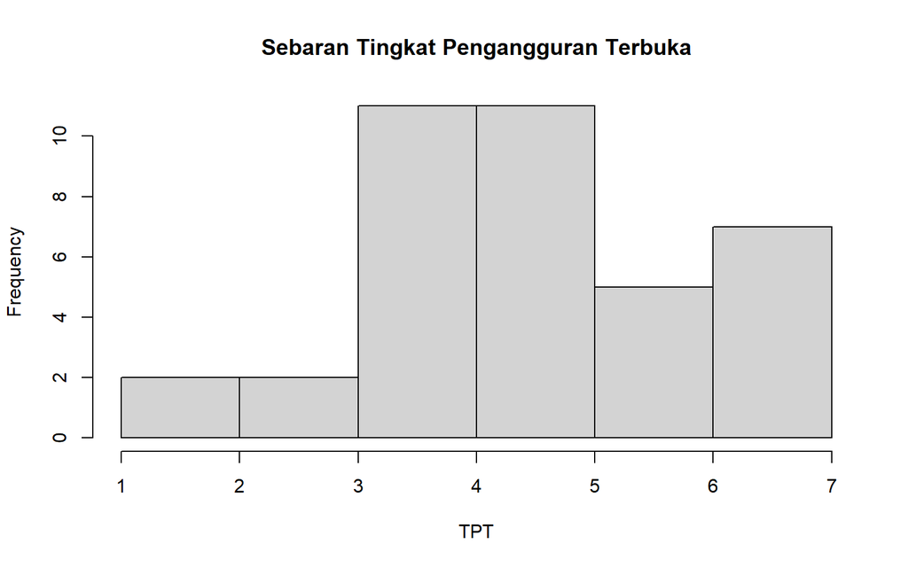

```r
hist(dt$Y,
     main="Sebaran Tingkat Pengangguran Terbuka",
     xlab="TPT")
```

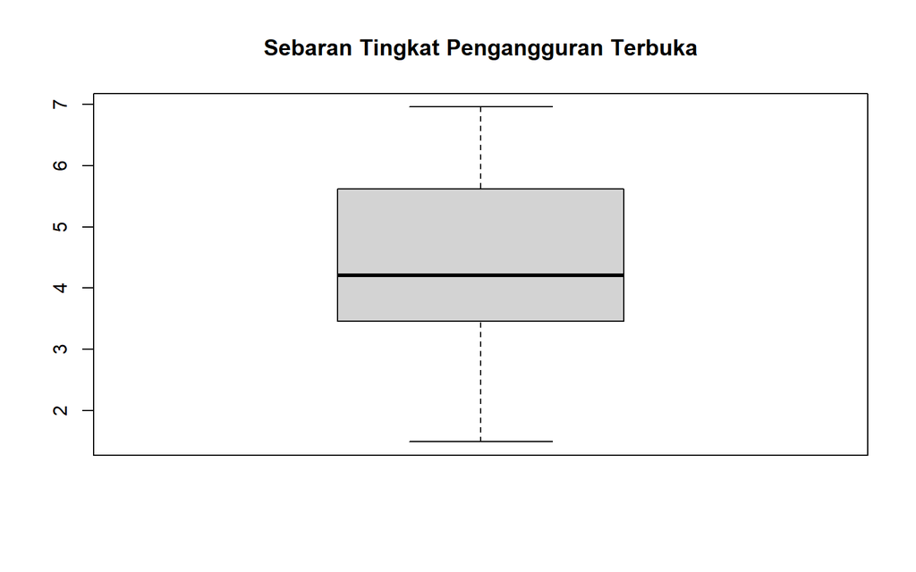

```r
boxplot(dt$Y,
        main="Sebaran Tingkat Pengangguran Terbuka")
```

## Peubah Penjelas VS Peubah REspon

### X1

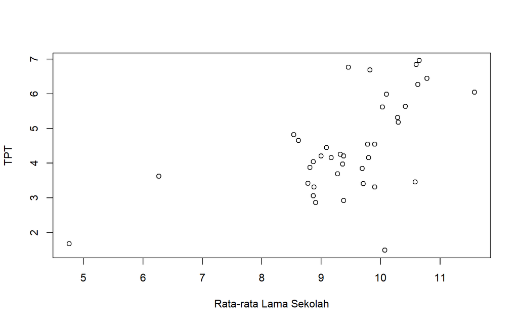

```r
plot(dt$X1, dt$Y,
     xlab="Rata-rata Lama Sekolah",
     ylab="TPT")
```

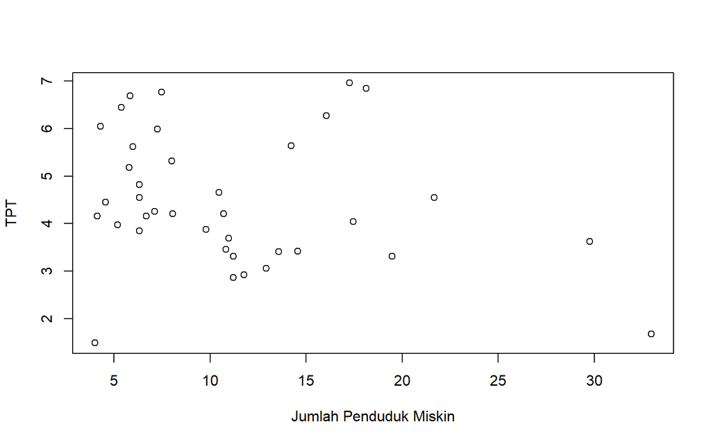

```r
plot(dt$X2, dt$Y,
     xlab="Jumlah Penduduk Miskin",
     ylab="TPT")
```

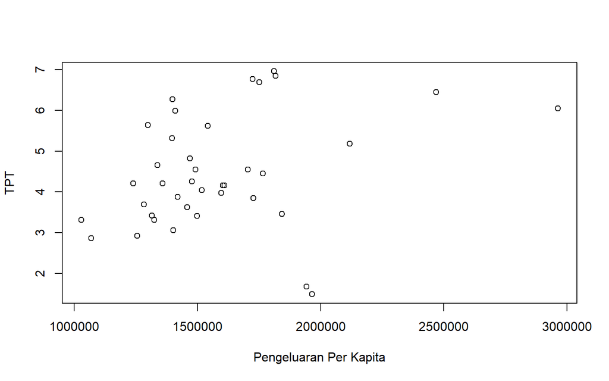

```r
plot(dt$X3, dt$Y,
     xlab="Pengeluaran Per Kapita",
     ylab="TPT")
```

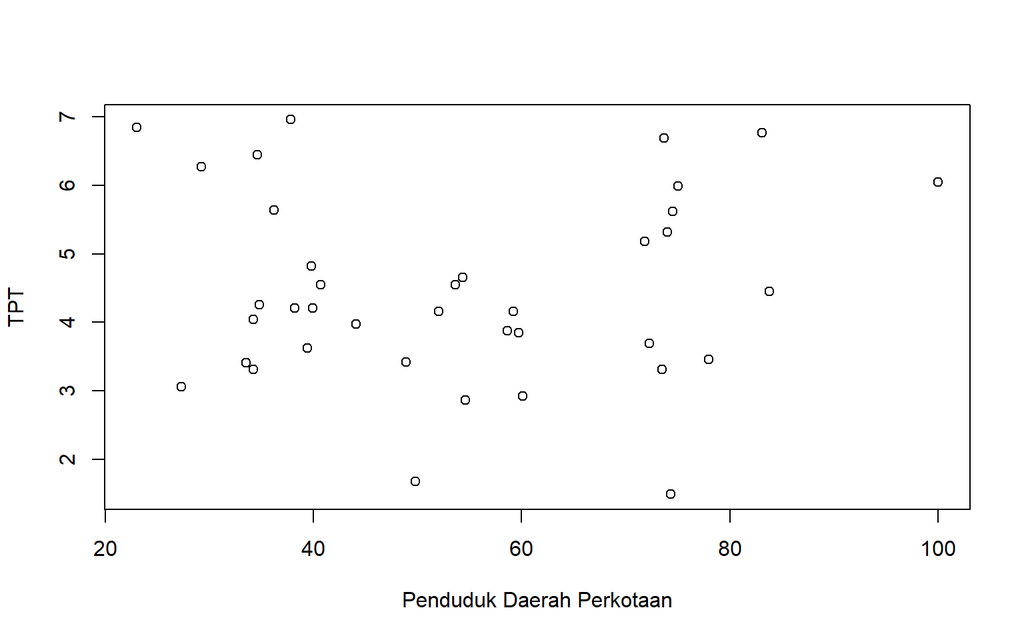

```r
plot(dt$X4, dt$Y,
     xlab="Penduduk Daerah Perkotaan",
     ylab="TPT")
```

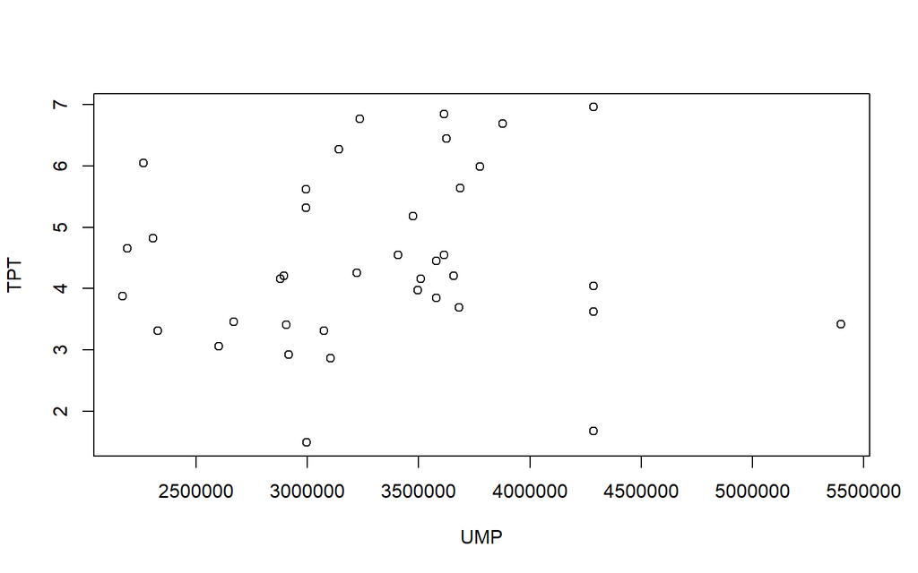

```r
plot(dt$X5, dt$Y,
     xlab="UMP",
     ylab="TPT")
```

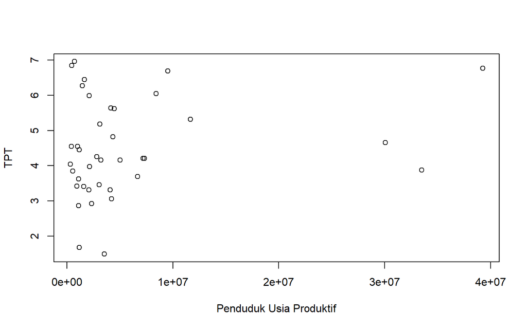

```r
plot(dt$X6, dt$Y,
     xlab="Penduduk Usia Produktif",
     ylab="TPT")
```

## Korelasi

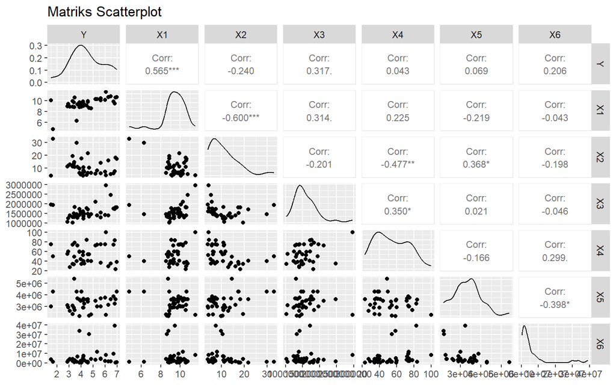

```r
ggpairs(
dt,
upper=list(continuous=wrap("cor", size=3)),
title="Matriks Scatterplot"
)
```

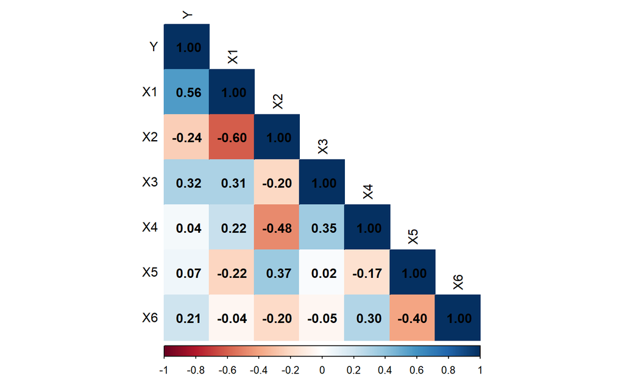

```r
cor_matrix <- cor(dt)

corrplot(
cor_matrix,
method="color",
type="lower",
addCoef.col="black",
tl.col="black"
)
```

## Permodelan

```r
model1 <- lm(Y ~ ., data=dt)

summary(model1)
```

```
##
## Call:
## lm(formula = Y ~ ., data = dt)
##
## Residuals:
##      Min       1Q   Median       3Q      Max
## -2.94623 -0.56122  0.07102  0.50524  1.79175
##
## Coefficients:
##               Estimate Std. Error t value Pr(>|t|)
## (Intercept) -6.243e+00  2.320e+00  -2.691 0.011373 *
## X1           7.971e-01  1.867e-01   4.269 0.000172 ***
## X2           1.442e-02  3.610e-02   0.399 0.692293
## X3           7.995e-07  5.134e-07   1.557 0.129578
## X4          -1.694e-02  1.090e-02  -1.554 0.130419
## X5           6.770e-07  2.843e-07   2.381 0.023573 *
## X6           7.153e-08  2.166e-08   3.302 0.002422 **
## ---
## Signif. codes:  0 '***' 0.001 '**' 0.01 '*' 0.05 '.' 0.1 ' ' 1
##
## Residual standard error: 1.016 on 31 degrees of freedom
## Multiple R-squared:  0.5469, Adjusted R-squared:  0.4592
## F-statistic: 6.236 on 6 and 31 DF,  p-value: 0.0002237
```

```r
coef(model1)
```

```
##   (Intercept)            X1            X2            X3            X4
## -6.243305e+00  7.971334e-01  1.442155e-02  7.995293e-07 -1.693898e-02
##            X5            X6
##  6.770238e-07  7.153283e-08
```

# Pemeriksaan Multikolinearitas

## Peubahan Peubah

```r
mod1 <- lm(Y~X1, dt)

mod2 <- lm(Y~X1+X2, dt)

mod3 <- lm(Y~X1+X2+X3, dt)

mod4 <- lm(Y~X1+X2+X3+X4, dt)

mod5 <- lm(Y~X1+X2+X3+X4+X5, dt)

mod6 <- lm(Y~., dt)

stargazer(
mod1,mod2,mod3,mod4,mod5,mod6,
type="text",
single.row=TRUE
)
```

```
##
## ========================================================================================================================================================
##                                                                             Dependent variable:
##                     ------------------------------------------------------------------------------------------------------------------------------------
##                                                                                      Y
##                              (1)                    (2)                   (3)                   (4)                   (5)                   (6)
## --------------------------------------------------------------------------------------------------------------------------------------------------------
## X1                     0.656*** (0.160)      0.763*** (0.200)      0.708*** (0.206)      0.684*** (0.211)      0.691*** (0.210)      0.797*** (0.187)
## X2                                             0.032 (0.035)         0.032 (0.035)         0.020 (0.040)         0.008 (0.041)         0.014 (0.036)
## X3                                                                 0.00000 (0.00000)     0.00000 (0.00000)     0.00000 (0.00000)     0.00000 (0.00000)
## X4                                                                                        -0.008 (0.012)        -0.008 (0.012)        -0.017 (0.011)
## X5                                                                                                             0.00000 (0.00000)    0.00000** (0.00000)
## X6                                                                                                                                 0.00000*** (0.00000)
## Constant                -1.733 (1.521)        -3.101 (2.160)        -3.525 (2.190)        -2.943 (2.384)        -3.877 (2.525)       -6.243** (2.320)
## --------------------------------------------------------------------------------------------------------------------------------------------------------
## Observations                  38                    38                    38                    38                    38                    38
## R2                          0.319                  0.334                 0.356                 0.365                 0.388                 0.547
## Adjusted R2                 0.300                  0.296                 0.300                 0.288                 0.292                 0.459
## Residual Std. Error    1.156 (df = 36)        1.159 (df = 35)       1.156 (df = 34)       1.166 (df = 33)       1.162 (df = 32)       1.016 (df = 31)
## F Statistic         16.867*** (df = 1; 36) 8.787*** (df = 2; 35) 6.277*** (df = 3; 34) 4.733*** (df = 4; 33) 4.049*** (df = 5; 32) 6.236*** (df = 6; 31)
## ========================================================================================================================================================
## Note:                                                                                                                        *p<0.1; **p<0.05; ***p<0.01
```

## VIF

```r
vif(model1)
```

```
##       X1       X2       X3       X4       X5       X6
## 1.770442 2.127371 1.269797 1.571744 1.354049 1.345414
```

# Diagnostik Sisaan

## Normalitas

```r
shapiro.test(residuals(model1))
```

```
##
##  Shapiro-Wilk normality test
##
## data:  residuals(model1)
## W = 0.95954, p-value = 0.1834
```

## Homoskedastisitas

```r
bptest(model1)
```

```
##
##  studentized Breusch-Pagan test
##
## data:  model1
## BP = 3.2278, df = 6, p-value = 0.7798
```

## Independensi

```r
dwtest(model1)
```

```
##
##  Durbin-Watson test
##
## data:  model1
## DW = 2.477, p-value = 0.9011
## alternative hypothesis: true autocorrelation is greater than 0
```

## OUtlier dan Influence

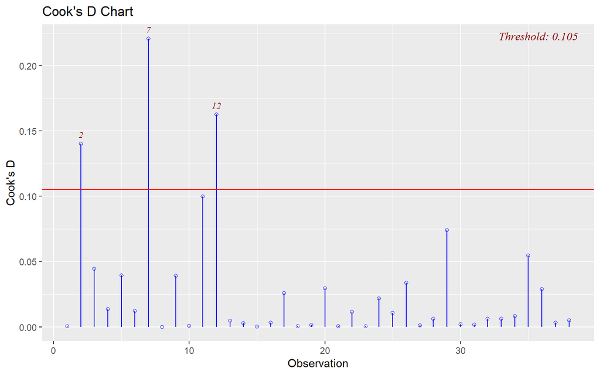

```r
ols_plot_cooksd_chart(model1)
```

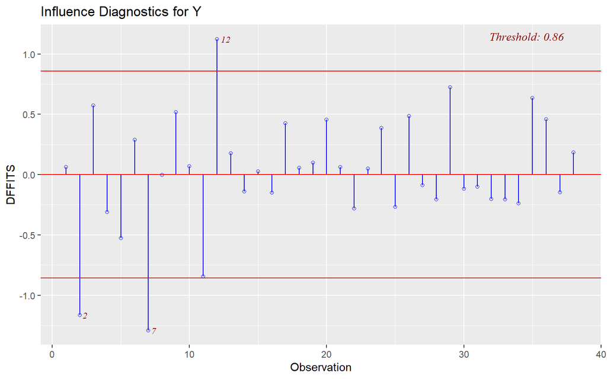

```r
ols_plot_dffits(model1)
```

# Model Akhir

```r
summary(model1)
```

```
##
## Call:
## lm(formula = Y ~ ., data = dt)
##
## Residuals:
##      Min       1Q   Median       3Q      Max
## -2.94623 -0.56122  0.07102  0.50524  1.79175
##
## Coefficients:
##               Estimate Std. Error t value Pr(>|t|)
## (Intercept) -6.243e+00  2.320e+00  -2.691 0.011373 *
## X1           7.971e-01  1.867e-01   4.269 0.000172 ***
## X2           1.442e-02  3.610e-02   0.399 0.692293
## X3           7.995e-07  5.134e-07   1.557 0.129578
## X4          -1.694e-02  1.090e-02  -1.554 0.130419
## X5           6.770e-07  2.843e-07   2.381 0.023573 *
## X6           7.153e-08  2.166e-08   3.302 0.002422 **
## ---
## Signif. codes:  0 '***' 0.001 '**' 0.01 '*' 0.05 '.' 0.1 ' ' 1
##
## Residual standard error: 1.016 on 31 degrees of freedom
## Multiple R-squared:  0.5469, Adjusted R-squared:  0.4592
## F-statistic: 6.236 on 6 and 31 DF,  p-value: 0.0002237
```

1. Uji Simultan (Uji F)

Nilai F-statistic = 6,236 dengan p-value = 0,0002237 (< 0,05).

Interpretasi: Secara simultan terdapat minimal satu peubah penjelas yang berpengaruh signifikan terhadap Tingkat Pengangguran Terbuka (TPT), sehingga model regresi layak digunakan.

2. Koefisien Determinasi (R²)

Nilai R² = 0,5469 dan Adjusted R² = 0,4592.

Interpretasi: Sebesar 54,69% variasi Tingkat Pengangguran Terbuka dapat dijelaskan oleh peubah:

X1 = Rata-rata Lama Sekolah X2 = Jumlah Penduduk Miskin X3 = Pengeluaran Per Kapita X4 = Penduduk Daerah Perkotaan X5 = UMP X6 = Penduduk Usia Produktif

Sedangkan 45,31% lainnya dijelaskan faktor lain di luar model.

3. Uji Parsial (Uji t)

Interpretasi masing-masing:

X1 (Rata-rata Lama Sekolah) → p-value = 0,000172 < 0,05 → berpengaruh signifikan positif terhadap TPT. Setiap kenaikan 1 tahun rata-rata lama sekolah, diperkirakan meningkatkan TPT sebesar 0,797 poin (dengan variabel lain tetap). X2 (Jumlah Penduduk Miskin) → p-value = 0,692 > 0,05 → tidak berpengaruh signifikan terhadap TPT. X3 (Pengeluaran Per Kapita) → p-value = 0,130 > 0,05 → tidak berpengaruh signifikan. X4 (Penduduk Daerah Perkotaan) → p-value = 0,130 > 0,05 → tidak berpengaruh signifikan. X5 (UMP) → p-value = 0,024 < 0,05 → berpengaruh signifikan positif terhadap TPT. X6 (Penduduk Usia Produktif) → p-value = 0,002 < 0,05 → berpengaruh signifikan positif terhadap TPT.

4. Pemeriksaan Asumsi

Normalitas (Shapiro–Wilk) p-value = 0,1834 > 0,05 → Sisaan berdistribusi normal.

Homoskedastisitas (Breusch–Pagan) p-value = 0,7798 > 0,05 → Tidak terdapat heteroskedastisitas (ragam sisaan homogen).

Independensi (Durbin–Watson) p-value = 0,9011 > 0,05 → Tidak terdapat autokorelasi pada sisaan.

Kesimpulan:

Model regresi memenuhi asumsi dasar dan layak digunakan. Dari enam peubah penjelas, Rata-rata Lama Sekolah (X1), UMP (X5), dan Penduduk Usia Produktif (X6) berpengaruh signifikan terhadap Tingkat Pengangguran Terbuka.